# Time Series Homework: Chapter 3 Lesson 2 Key

## Data

```r
mortality <- rio::import("https://byuistats.github.io/timeseries/data/mortality_us.xlsx")
```

## Questions

### Question 1 - Context and Measurement (10 points)

The first part of any time series analysis is context. You cannot properly analyze data without knowing what the data is measuring. Without context, the most simple features of data can be obscure and inscrutable. This homework assignment will center around the series below.

Please research the time series. In the spaces below, give the data collection process, unit of analysis, and meaning of each observation for the series.

#### **US Mortality**

https://wonder.cdc.gov/wonder/help/cmf.html#

Note: The data is self-explanatory, don’t get lost in the documentation page.

**Answer**

**Data Collection Process:**

The CDC collects data on the number of deaths in the US from the Compressed Mortality File which is a data base updated annually.

**Unit of Analysis:**

Deaths per 100,000 people in the United States

**Meaning:**

Each observation is the total number of deaths that year, the population and the mortality rate per 100,000 people.

### Question 2 - US Mortality Rate: Visualization (30 points)

##### a) Please plot the US Mortality Rate series (mortality per 100,000).

**Answer**

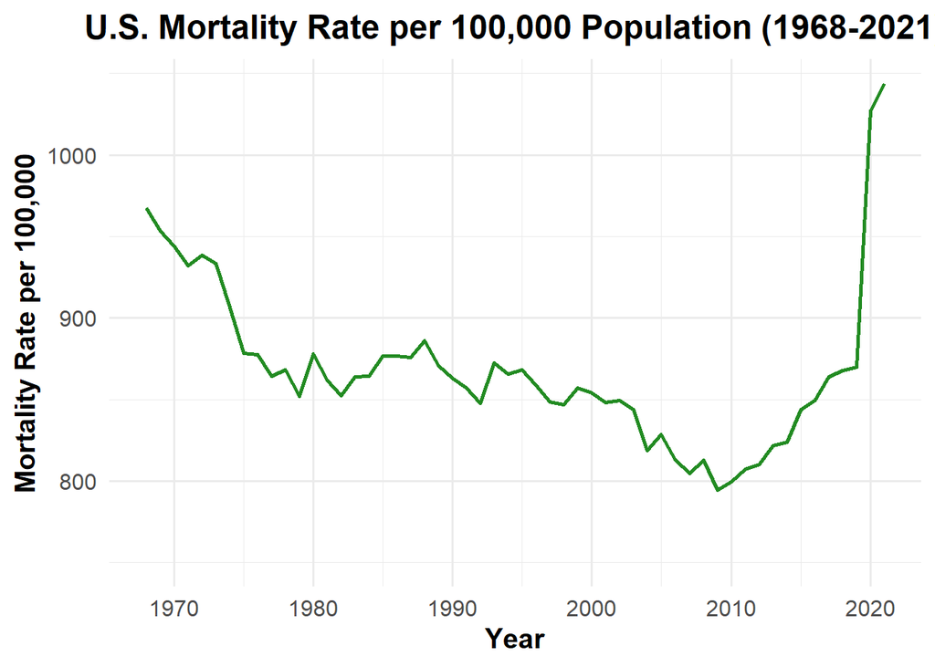

```r
ggplot(mortality, aes(x = year, y = `mort_rate_per_100,000`)) +
  geom_line(color = "forestgreen", size = 1) +
  labs(
    title = "U.S. Mortality Rate per 100,000 Population (1968-2021)",
    x = "Year",
    y = "Mortality Rate per 100,000",
  ) +
  theme_minimal(base_size = 15) +
  theme(
    plot.title = element_text(hjust = 0.5, face = "bold"),
    axis.title.x = element_text(face = "bold"),
    axis.title.y = element_text(face = "bold"),
    plot.caption = element_text(hjust = 0.5, face = "italic", color = "gray40")  # Style the subnote
  ) +
  ylim(750, max(mortality$`mort_rate_per_100,000`))  # Set y-axis starting from 800
```

##### b) Use the exponential smoothing method to model the US Mortality Rate series. Use the smoothing parameter that R calculates by minimizing the SS1PE. Add it to the plot in 2a

**Answer**

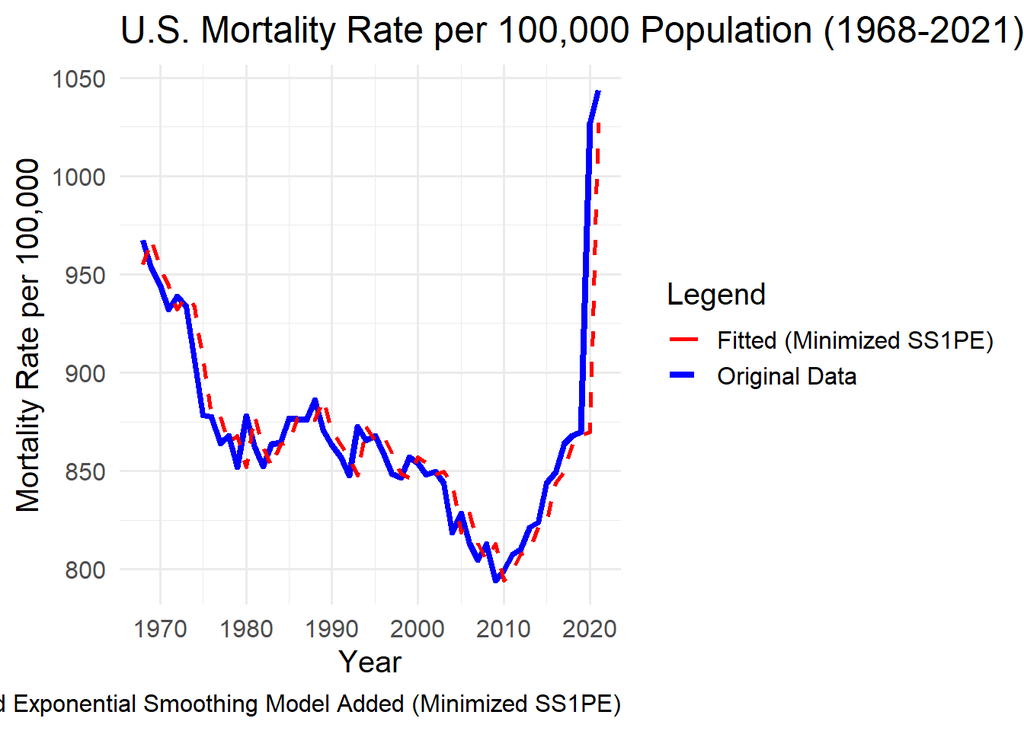

```r
mortality_tsibble <- mortality |>
  as_tsibble(index = year)

mortality_model <- mortality_tsibble |>
  model(
    Additive = ETS(`mort_rate_per_100,000` ~
                     error("A") +
                     trend("N", beta = 0) +
                     season("N"),  # No trend or seasonality, pure EWMA
                   opt_crit = "amse")  # Minimize SS1PE using AMSE
  )

fitted_values <- fitted(mortality_model)

# Add the fitted values to the plot and include a legend
ggplot() +
  geom_line(data = mortality, aes(x = year, y = `mort_rate_per_100,000`, color = "Original Data"), size = 1.5) +
  geom_line(data = fitted_values, aes(x = year, y = .fitted, color = "Fitted (Minimized SS1PE)"), size = 1, linetype = "dashed") +
  labs(
    title = "U.S. Mortality Rate per 100,000 Population (1968-2021)",
    x = "Year",
    y = "Mortality Rate per 100,000",
    caption = "Fitted Exponential Smoothing Model Added (Minimized SS1PE)"
  ) +
  theme_minimal(base_size = 15) +
  scale_color_manual(name = "Legend", values = c("Original Data" = "blue", "Fitted (Minimized SS1PE)" = "red")) +
  guides(color = guide_legend(override.aes = list(linetype = c("solid", "dashed"))))
```

##### c) Please repeat the modeling above but instead choose a smoothing parameter value $\alpha=0.2$. Add it to the plot in 2a

**Answer**

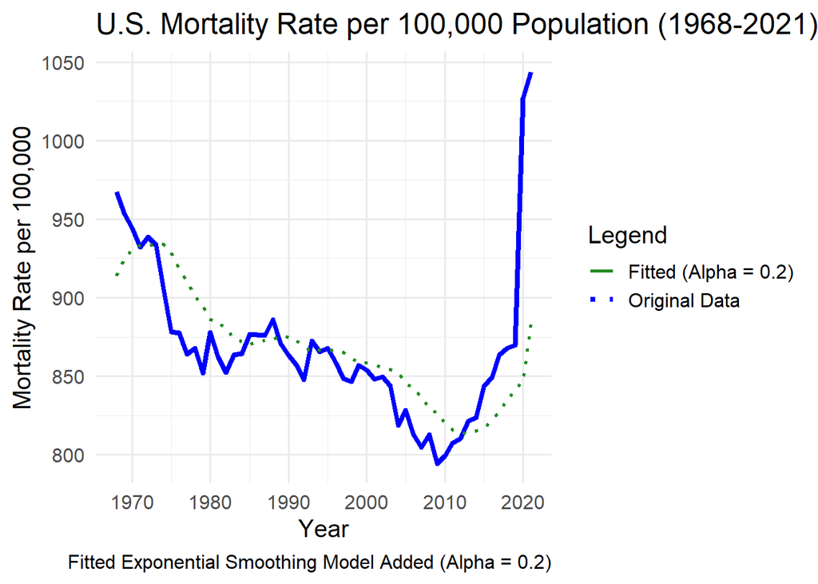

```r
mortality_model_alpha_0.2 <- mortality_tsibble |>
  model(
    Additive = ETS(`mort_rate_per_100,000` ~
                     error("A") +
                     trend("N", alpha = 0.2, beta = 0) +
                     season("N"),  # No trend or seasonality, pure EWMA
                   opt_crit = "amse")
  )

fitted_values_alpha_0.2 <- fitted(mortality_model_alpha_0.2)

# Add the fitted values to the plot and include a legend
ggplot() +
  geom_line(data = mortality, aes(x = year, y = `mort_rate_per_100,000`, color = "Original Data"), size = 1.5) +
  geom_line(data = fitted_values_alpha_0.2, aes(x = year, y = .fitted, color = "Fitted (Alpha = 0.2)"), size = 1, linetype = "dotted") +
  labs(
    title = "U.S. Mortality Rate per 100,000 Population (1968-2021)",
    x = "Year",
    y = "Mortality Rate per 100,000",
    caption = "Fitted Exponential Smoothing Model Added (Alpha = 0.2)"
  ) +
  theme_minimal(base_size = 15) +
  scale_color_manual(name = "Legend", values = c("Original Data" = "blue", "Fitted (Alpha = 0.2)" = "forestgreen")) +
  guides(color = guide_legend(override.aes = list(linetype = c("solid", "dotted"))))
```

##### d) Please repeat the modeling above but instead choose a smoothing parameter value $\alpha=\frac{1}{n}$.Add it to the plot in 2a

**Answer**

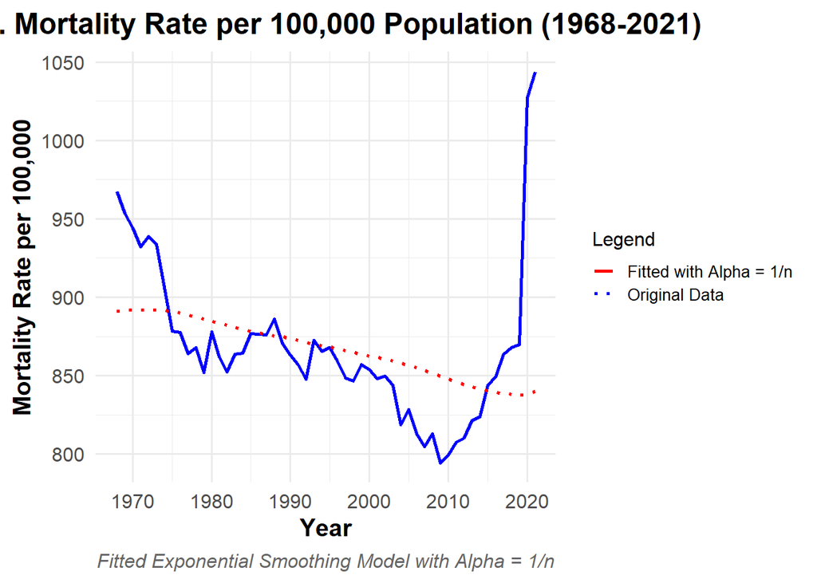

```r
# Assuming your mortality data is already in a time series format
n <- length(mortality$`mort_rate_per_100,000`)  # Number of data points
alpha <- 1 / n  # Smoothing parameter alpha = 1/n

mortality_tsibble <- mortality |>
  as_tsibble(index = year)
mortality_model <- mortality_tsibble |>
  model(
    Additive = ETS(`mort_rate_per_100,000` ~ error("A") + trend("A" , alpha = alpha, beta=0) + season("N"),
                   opt_crit = "amse")  # Minimize SS1PE using AMSE
  )

fitted_values_alpha_1_n <- fitted(mortality_model)

# Add the fitted values to the plot and include a legend
ggplot() +
  # Plot the original data in blue
  geom_line(data = mortality, aes(x = year, y = `mort_rate_per_100,000`, color = "Original Data"), size = 1) +

  # Add the fitted values from the exponential smoothing model in red with customized dash pattern
  geom_line(aes(x = fitted_values_alpha_1_n$year, y = fitted_values_alpha_1_n$.fitted, color = "Fitted with Alpha = 1/n"), size = 1, linetype = "dotted") +

  # Labels and title
  labs(
    title = "U.S. Mortality Rate per 100,000 Population (1968-2021)",
    x = "Year",
    y = "Mortality Rate per 100,000",
    caption = "Fitted Exponential Smoothing Model with Alpha = 1/n"
  ) +

  # Customize the theme
  theme_minimal(base_size = 15) +
  theme(
    plot.title = element_text(hjust = 0.5, face = "bold"),
    axis.title.x = element_text(face = "bold"),
    axis.title.y = element_text(face = "bold"),
    plot.caption = element_text(hjust = 0.5, face = "italic", color = "gray40"),

    # Make the legend smaller if needed
    legend.text = element_text(size = 10),
    legend.title = element_text(size = 12),
    legend.key.size = unit(0.5, 'cm'),
    legend.spacing.x = unit(0.2, 'cm')
  ) +
  # Add the legend
  scale_color_manual(name = "Legend", values = c("Original Data" = "blue", "Fitted with Alpha = 1/n" = "red")) +
  guides(color = guide_legend(override.aes = list(linetype = c("solid", "dotted"))))
```

##### d) Which of the smoothing parameter values you tried before work best for the series? Justify your answer.

**Answer**

### Question 5 - US Mortality Rate: Excess Mortality (30 points)

The jump at the last two years of the US Mortality Rate series is clearly the effect that Covid-19 had on mortality across the US.

##### a) Please calculate the excess mortality rate during 2020 and 2021 using the smoothing parameter values you employed in the previous question. Your results should be displayed in a table that is professionally formatted.

**Answer**

```r
# Filter data for 2020 and 2021
fitted_covid_ss1pe <- fitted_values |> filter(year %in% c(2020, 2021))
fitted_covid_alpha_0.2 <- fitted_values_alpha_0.2 |> filter(year %in% c(2020, 2021))
fitted_covid_alpha_1_n <- fitted_values_alpha_1_n |> filter(year %in% c(2020, 2021))

# Compute excess values for each alpha
mortality_covid <- mortality |>
  filter(year %in% c(2020, 2021)) |>
  mutate(
    ss1pe = `mort_rate_per_100,000` - fitted_covid_ss1pe$.fitted,
    alpha_0.2 = `mort_rate_per_100,000` - fitted_covid_alpha_0.2$.fitted,
    alpha_1_n = `mort_rate_per_100,000` - fitted_covid_alpha_1_n$.fitted
  )

# Create the table
library(pander)
pander(
  mortality_covid |> select(year, `mort_rate_per_100,000`,
                            ss1pe, alpha_0.2, alpha_1_n),
  caption = "Mortality Data for 2020-2021 with Excess Values Calculated for Three Different Alphas"
)
```

Mortality Data for 2020-2021 with Excess Values Calculated for Three Different Alphas

| year | mort_rate_per_100,000 | ss1pe | alpha_0.2 | alpha_1_n |
| --- | --- | --- | --- | --- |
| 2020 | 1027 | 157.3 | 179.9 | 189.5 |
| 2021 | 1044 | 16.82 | 160.7 | 203.7 |

##### b) What is the meaning of excess mortality as you calculated it? Please explain it to a general audience, as if you were being interviewed in a national news show.

**Answer**

Excess mortality refers to the number of deaths beyond what is typically expected in a specific period, based on historical data. It serves as an indicator of unusual circumstances, like pandemics, natural disasters, or severe flu seasons, showing if more people are dying than usual. This metric captures both direct effects, such as deaths from the primary cause (e.g., a virus), and indirect impacts, like deaths resulting from overwhelmed healthcare systems. By comparing observed deaths to expected baselines, experts can assess the overall impact of such events on public health.

##### c) Which excess mortality rate estimate do you think is correct? Some commentators would suggest you are choosing the parameters to defend your political goals, not to conduct a scientific analysis. Please comment on the difficulty of choosing parameter values to estimate the death toll of Covid-19.

**Answer**

### Rubric

[output not shown]